# Alcohol consumption

### Abstract

The aim of this project is to discover and identify the relationships between alcohol consumption and other physical and social variables of the individuals. For achieving this we explored the dataset of the [National Health survey of United States](https://www.kaggle.com/cdc/national-health-and-nutrition-examination-survey#questionnaire.csv).

The main challenge we had to face was to select from over 2000 variables available in the dataset only those that were useful for our research. Apart from that, we had to transform the encountered variables and subsistute missing values from the response variable.

### Introduction

Is alcohol consumption related to factors such as mental health, marital status, income, gender and age?

We did not have a very specific question in mind as we were more curious to analyze the factors related to alcohol consumption in general and find significant or unexpected insights. Some of our initial questions lead us to dead-ends after analyzing the data more in depth, this is why we decided to focus on a broader research, centered around alcohol consumption and with a focus on mental health and personal situations.

One of the initial purposes of developing this project was to find out how mental health relates to alcohol consumption and this has been quite challenging. Establishing this correlation could potentially raise awareness on how alcohol consumption might affect the mental health or that certain untreated mental issues could lead to higher amount consumptions. We were also interested in knowing how alcohol consumption relates to income. For instance, if people of lower income or higher income tend to consume more alcohol. This could potentially raise awareness of vicious cycles in our society. This study could also help verify or deny common beliefs or expectations. For instance, do males consume more alcohol than females? Do married people consume less alcohol than the single and separated/widowed ones? All these could show results that would futher lead researches to continue with more in depth analysis such as why certain relations exist.

### Related Work

##### **Project 1**: [How common is alcohol and drug dependency across the world?](https://ourworldindata.org/alcohol-and-drug-dependency)

This project from the website *Our World in Data* presents the trends in alcohol consumption and substance use in countries all over the world, with data from 1990 to 2016. The aim is to give a better understanding of the global prevalence of substance use disorders.

Some of the conclusions in the research are:

- Across most countries, the number of alcohol use disorders is higher than other drug use disorders.
- Substance use disorders are more common among men than women.

This project carried out by the World Health Organization provide an interactive graph where we can see the age-standardized death rate per 100000 related to alcohol. The study includes causes such as cancer of esophagus and larynx, alcohol dependence syndrome, chronic liver disease, cirrhosis etc.

##### **Project 3:** [Alcohol as a risk factor for type 2 diabetes](https://care.diabetesjournals.org/content/32/11/2123.full-text.pdf)

This study by the University of Toronto tries to measure the relation between alcohol consumption and the presence of type 2 diabetes. For obtaining the data, the researchers have found several data sources both from public sources or from previous articles.

The main conclusion of this study is that a relationship exists between alcohol consumption and the presence or diabetes in an *u-shaped* way, both for men and women.

##### **Project 4:** Risk thresholds for alcohol consumption: combined analysis of individual-participant data for 599 912 current drinkers in 83 prospective studies

One of the reasons behind initializing this project by Angela M Wood et al. was the fact that there is no universal low-risk limit for alcohol consumption. In order to define this threshold - to see how much alcohol can be tolerated without causing significant harm - the researchers studied individual-participant data from 599912 current drinkers without previous cardiovascular disease.

The main finding was that the threshold for lowest risk for all-cause mortality was about 100 g per week. Long-term reduction of alcohol consumption (below the limit recommended in US guidelines) was associated with an increase of longer life expectancy. Exploratory analyses suggested that drinkers of beer or spirits, as well as binge drinkers, had the highest risk for all-cause mortality.

##### **Project 5:** [Consuming Alcohol in Moderation Can Lower Mortality Risks](https://www.acc.org/latest-in-cardiology/articles/2017/08/14/12/54/consuming-alcohol-in-moderation-can-lower-mortality-risks)

This is a study conducted by Bo Xi et al. and published in the Journal of the American College of Cardiology. As in the fourth project, heavy or binge drinking was associated with increased risk of all-cause mortality, while light and moderate alcohol intake might have, according to their study, a protective effect on all-cause and CVD-specific mortality in U.S. adults.

### Exploratory Data Analysis

### Data Source: [National health and nutrition examination survey](https://www.kaggle.com/cdc/national-health-and-nutrition-examination-survey)

This data was obtained by the United States center of health statistics. It is an annual survey done for the civilian resident population of the United States. This is the public dataset corresponding to the period 2013-2014, and it was saved in the following folder: /data/national-health-survey/

The data collection of this survey was a complex task that involved several parts, starting with body measurements to questionnaires to evaluate the mental health. A further description of the methodology can be found [here](https://www.cdc.gov/nchs/data/series/sr_01/sr01_056.pdf).

### Data description

The dataset is divided in several sections: demographic, examinations, dietary data, laboratory, medications and questionnaires. For our study, we are going to focus on the questionnaire section, taking some columns from demographic (such as Gender, Age or Marital status) and from Laboratory (HasHIV). The variables in the questionary dataset refer to a response for a certain question, such as: *In the past 12 months, how often did you drink any type of alcoholic beverage?* The selected datasets are composed of 10175 rows and 1422 columns. For instance, 15 of those columns refer to answers for questions related with alcohol consumption and 22 are related with mental health.

In order to select the interesting variables for our research question, we reserach over the 1422 variables in the 3 selected datasets for questions that could be related with alcohol consumption. After doing so, we had to rename the variable codes to a readable description of the column, in order to be able to work in a more usable way with them. Not only we renamed the variables but the possible values that those variables could have. For instance, the possible values for indicating the marital status of an individual were codes from `1 to 6`, where `1` meant `Married`, `2` was `Widowed` and so on. A huge advantage in the process is the great documentation of the dataset, given a variable code, it was well explained in the **National Center for Health Statistics** website.

We considered 44 variables from the total 1422, which are described in a more detailed manner at the [data folder](https://github.com/angeligareta/AlcoholConsumption/tree/master/data). Some of the features we considered during our analysis were the following:

- Age: `0 to 79: Range of years, 80: 80+ years`
- Gender: `1: Female, 2: Male`
- MaritalStatus: `1: Married, 2: Widowed, 3: Divorced, 4: Separated, 5: Never Married and 6: Living with partner`
- HighestEducationLevel: `Less than 9th grade, 9-11th grade, High School, College, College graduate or above`
- DifficultyConcentrating: `1: Yes, 2: No`
- HadHPV: `1: Yes, 2: No`
- ProblemsRememberingThingsLast30d: `1: Never, 2: About once, 3: Two or three times, 3: Nearly every day, 4: Several times a day`
- AlcoholAmountAvg: `0 to 365: range of values`
- AlcoholAmountUnit: Explains the unit of the value in `AlcoholAmountAvg`, that can be `1: Week, 2: Month` or `3: Year`
- MonthlyFamilyIncome
- FamilyPovertyIndex
- AlcoholDrink5Last30d

And finally, we have three variables selected for alcohol consumption. One is `AlcoholDrink5Last30d`, which we could not use as there were missing many of the values, and `AlcoholAmountAvg` and `AlcoholAmountUnit`. In order to have the AlcoholAmountAvg in the same unit, we had to normalize the variable and transform the values to store the AlcoholAmountAvg per month. In order to do so, if the unit was week, we multiplied the value by 4, otherwise, if it was Year, it would be divided by 12. After that, we are going to select that new variable `AlcoholAmountAvgPerMonth` as our response variable.

### Data Preprocess

#### Data Transformation

All the data transformation and preprocessing can be found in the [preprocessing file](https://github.com/angeligareta/AlcoholConsumption/blob/master/src/preprocessing/preprocess.R).

First of all we joined the selected datasets by the SEQN number, which corresponds to the individual identification number. After that, we renamed the variables codes into a more readable name, as we explained in the previous section.

In the dataset, in some variables the repetition of 7’s (7, 77, 777, 7777) or 9’s (9, 99, 999, 9999) meant that the respondant refused to answer, so we had to replace them by NA, as they are not interesting in our research. Besides, we replaced the possible values of the selected categorical variables to readable factors.

#### New Data Variables

After doing an analysis of some of the selected variables, we added new columns to analyze if they could be useful. The added variables are:

- AlcoholAmountAvgPerMonth: As we explained in the previous section, we merged AlcoholAmountAvg and AlcoholAmountUnit variables in a smart way to come with a new variable that would represent the AlcoholAmountAvg of the individuals per month.
- AlcoholAmountAvgPerMonthCubeRoot: After analyzing the skewness of our response variable AlcoholAmountAvgPerMonth, we found that it had a high right skewness of approxmately 2.0. We decided to transform the variable using cuberoot transformation, which resulted in a much better distribution of the data, with a skewness of 0.38, almost being a normal distribution. However, we have to take into account that the possible results of any model using this variable would be the cube root of the real one.

```r
# Skewness for AlcoholAmountAvgPerMonth
skewness(transformed_dataset$AlcoholAmountAvgPerMonth)
```

```
## [1] 2.056278
```

```r
# Skewness for cuberoot of AlcoholAmountAvgPerMonth
skewness(kader:::cuberoot(transformed_dataset$AlcoholAmountAvgPerMonth))
```

```
## [1] 0.3879408
```

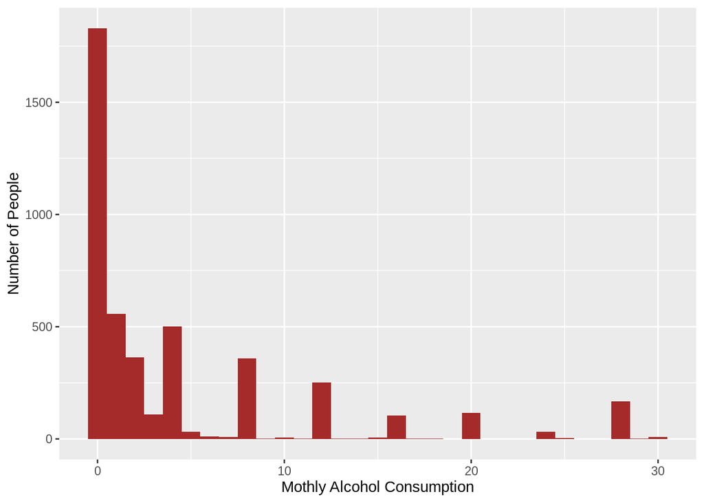

```r
ggplot(dataset, aes(AlcoholAmountAvgPerMonth)) +
  geom_histogram(fill = "brown", binwidth = 1) +
  ylab("Number of People") +
  xlab("Mothly Alcohol Consumption")
```

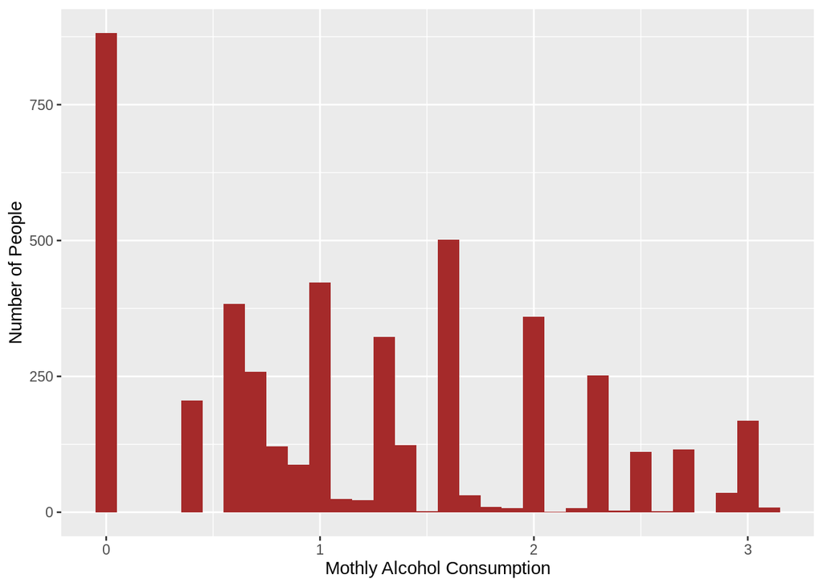

```r
ggplot(dataset,aes(kader:::cuberoot(dataset$AlcoholAmountAvgPerMonth))) +
  geom_histogram(fill = "brown", binwidth = 0.1) +
  ylab("Number of People") +
  xlab("Mothly Alcohol Consumption")
```

- HighestEducationLevelDisc: We decided to try discretizing the HighestEducationLevel variable. We splitted the 6 levels into “Basic”, “Intermediate” and “Advanced”.
- HadSTI: We grouped all the variables that refer to STI’s and we added a new column that indicates if the individual has had an STI.
- DrugUseLast30dSum: New variable that represents the sum of the number of days the individual has consumed any of the variables related to drugs such as `MethanfitamineLast30d`.
- DrugCigsUseLast30dSum: Same as the previous variable but considering cigs as a drug.
- DrugUseLast30d: Discretized variable of DrugUseLast30dSum, which represents if the individual used or did not use drugs in the last month, not giving importance to the exact amount.
- DrugCigsUseLast30d: Same as the previous discretized variable but with DrugCigsUseLast30dSum.

### Relationships among ariables

```r
cor(
  income_dataset$FamilyPovertyIndex,
  income_dataset$AlcoholAmountAvgPerMonth,
  method = "spearman"
)
```

```
## [1] 0.1922415
```

### Methods

- **Strength of relationships**:

  The formula that we are going to use for describing the relationships between the dependent and independent variables is:

  `AlcoholAmountAvgPerMonthCubeRoot = Gender + Age + FamilyPovertyIndex + HighestEducationLevelDisc + DrugCigsUseLast30dSum`

  As we can see we selected only a couple of variables from the list of transformed variables. The main numerical criteria for chosing them is because of they performacnce in a correlation test (Pearson and Spearman tests).

  Also, in a subjective perspective, we tried to add variables to the models that could be related with the alcohol consumption, in order to be relevant.

  Based on our dataset, we chose tree models for predicting the alcohol consumption. The idea is to test different approaches and choose the best one for our problem, according to the metrics.
- **Machine Learning Models used**:
  - **Linear model**

  The first and simplest approach is to use a linear model. We use the formula that we explained before, and then using metrics to test the result.

  ```r
    lm3 <- lm(AlcoholAmountAvgPerMonthCubeRoot ~ Gender + Age + FamilyPovertyIndex + HighestEducationLevelDisc + DrugCigsUseLast30dSum, dataset)
    summary(lm3)
  ```

  ```
  ##
  ## Call:
  ## lm(formula = AlcoholAmountAvgPerMonthCubeRoot ~ Gender + Age +
  ##     FamilyPovertyIndex + HighestEducationLevelDisc + DrugCigsUseLast30dSum,
  ##     data = dataset)
  ##
  ## Residuals:
  ##      Min       1Q   Median       3Q      Max
  ## -1.74234 -0.64900 -0.09702  0.56823  2.48966
  ##
  ## Coefficients:
  ##                                         Estimate Std. Error t value Pr(>|t|)
  ## (Intercept)                            1.1085801  0.0573763  19.321  < 2e-16
  ## GenderFemale                          -0.2204769  0.0272012  -8.105 6.98e-16
  ## Age                                   -0.0062009  0.0008028  -7.724 1.42e-14
  ## FamilyPovertyIndex                     0.1075641  0.0094397  11.395  < 2e-16
  ## HighestEducationLevelDiscIntermediate  0.0973722  0.0429226   2.269   0.0234
  ## HighestEducationLevelDiscAdvanced      0.2230031  0.0393117   5.673 1.51e-08
  ## DrugCigsUseLast30dSum                  0.0071328  0.0009871   7.226 5.96e-13
  ##
  ## (Intercept)                           ***
  ## GenderFemale                          ***
  ## Age                                   ***
  ## FamilyPovertyIndex                    ***
  ## HighestEducationLevelDiscIntermediate *
  ## HighestEducationLevelDiscAdvanced     ***
  ## DrugCigsUseLast30dSum                 ***
  ## ---
  ## Signif. codes:  0 '***' 0.001 '**' 0.01 '*' 0.05 '.' 0.1 ' ' 1
  ##
  ## Residual standard error: 0.8446 on 3884 degrees of freedom
  ##   (584 observations deleted due to missingness)
  ## Multiple R-squared:  0.09573,  Adjusted R-squared:  0.09434
  ## F-statistic: 68.53 on 6 and 3884 DF,  p-value: < 2.2e-16
  ```

  As we can see in the summary of the model training, all the variables are significant in the model, ussing a significance level of `95%`. This happens because all the *p-values* are less than `0.05`. Also, we can see that the linear model is significant because we have a *p-value* of `2.2e-16`, using a *F-statistic*.

  But, we have a problem with the `r-squared`, which have a value of `0.1` approximately. In our field, having this value could be considered enough, because we have more than 900 columns in our original dataset, but we are going to try to improve it, using a different model.
  - **Generalized linear model**

  We used the generalized linear model in order to improve the results of the basic linear model.

  ```r
  glm3 <- glm(AlcoholAmountAvgPerMonthCubeRoot ~ Gender + Age + FamilyPovertyIndex + HighestEducationLevelDisc + DrugCigsUseLast30dSum, data = dataset, family="gaussian")
  summary(glm3)
  ```

  ```
  ##
  ## Call:
  ## glm(formula = AlcoholAmountAvgPerMonthCubeRoot ~ Gender + Age +
  ##     FamilyPovertyIndex + HighestEducationLevelDisc + DrugCigsUseLast30dSum,
  ##     family = "gaussian", data = dataset)
  ##
  ## Deviance Residuals:
  ##      Min        1Q    Median        3Q       Max
  ## -1.74234  -0.64900  -0.09702   0.56823   2.48966
  ##
  ## Coefficients:
  ##                                         Estimate Std. Error t value Pr(>|t|)
  ## (Intercept)                            1.1085801  0.0573763  19.321  < 2e-16
  ## GenderFemale                          -0.2204769  0.0272012  -8.105 6.98e-16
  ## Age                                   -0.0062009  0.0008028  -7.724 1.42e-14
  ## FamilyPovertyIndex                     0.1075641  0.0094397  11.395  < 2e-16
  ## HighestEducationLevelDiscIntermediate  0.0973722  0.0429226   2.269   0.0234
  ## HighestEducationLevelDiscAdvanced      0.2230031  0.0393117   5.673 1.51e-08
  ## DrugCigsUseLast30dSum                  0.0071328  0.0009871   7.226 5.96e-13
  ##
  ## (Intercept)                           ***
  ## GenderFemale                          ***
  ## Age                                   ***
  ## FamilyPovertyIndex                    ***
  ## HighestEducationLevelDiscIntermediate *
  ## HighestEducationLevelDiscAdvanced     ***
  ## DrugCigsUseLast30dSum                 ***
  ## ---
  ## Signif. codes:  0 '***' 0.001 '**' 0.01 '*' 0.05 '.' 0.1 ' ' 1
  ##
  ## (Dispersion parameter for gaussian family taken to be 0.7134272)
  ##
  ##     Null deviance: 3064.3  on 3890  degrees of freedom
  ## Residual deviance: 2771.0  on 3884  degrees of freedom
  ##   (584 observations deleted due to missingness)
  ## AIC: 9737.3
  ##
  ## Number of Fisher Scoring iterations: 2
  ```

  As it happened with the previous model, all the variables are significative according to their *p-value*. But here the metric that we are going to use to measure the performance is the `AIC` (Akaike Information Criterion), which have a value of 9737.3
  - **Regression Tree**

    Finally, we used a decision tree, becouse there are relationships in our data that are not linear. For doing this, we applied `CrossValidation`, with `k = 10` folds. Also we add aparamter grid search which was used for choosing the best combination of parameters from a given list.

### Results (**20 points**)

As we can see the best result is the linear model with the discretized variables.

- **Strengths of relationships**:

Trying to correlate monthly average alcohol consumption with the Poverty Index, using the Spearman method resulted in a 19% correlation. Although it is also quite low, we can assume a weak correlation, especially given the social context.

```r
cor(
  income_dataset$FamilyPovertyIndex,
  income_dataset$AlcoholAmountAvgPerMonth,
  method = "spearman"
)
```

```
## [1] 0.1922415
```

### Discussion and Future Work (**10 points**)

The gender dependence was something we expected. In a new project this could futher be studied in relation to other variables, such as the amount of swear words used by each gender, crime activity and other factors that come in a full suite of cultural behaviour.

We also conclude that it is quite difficult to predict alcohol drinking habits as it is not strongly correlated to the factors about which we had information in the dataset.

It is also important to note that the data was gathered from questionnaires, therefore its accuracy is not granted. For future, it would also be interesting to work with datasets that have a different source such as purchase statements.

Finally, as we improve our data processing skills and come across better data and in greater amounts, it would be ideal if we could use artificial neural networks to find patterns regarding alcohol consumption and mental health, as there migt be some tings that we are unable to detect using other methods. The results could potentially show the risks involved with alcohol consumption.